# Entregable 1: Modelización del consumo en el equipo de auxiliares

Moises Britez

2025-11-01

## Planteamiento y flujo de trabajo

En este documento se cubren los siete apartados solicitados en el enunciado. La estructura general es:

1. Carga y revisión de los datos (`Entregable1.RData`).
2. Limpieza y filtrado de eventos.
3. Comparativa de consumos y potencias por tipo de evento.
4. Modelización lineal con la primera quincena de septiembre.
5. Diagnóstico del modelo y análisis de significancia.
6. Validación con la segunda quincena.
7. Generación de un modelo predictivo más complejo y selección del modelo final.

### Resumen ejecutivo

**Objetivo**: Modelizar el consumo energético de los equipos auxiliares de trenes en función de variables operativas y de climatización.

**Datos**: Eventos registrados durante septiembre de 2019, con información sobre duración, tipo de evento, consumo energético y variables de compresores y calefacción.

**Metodología**: - Limpieza y filtrado de datos (eventos válidos con duración ≤ 600 segundos) - Análisis exploratorio y pruebas de hipótesis (t-test) - Modelización lineal múltiple (interpretable) - Modelización con Random Forest (mayor capacidad predictiva) - Validación temporal (primera quincena para entrenamiento, segunda para validación)

**Resultados esperados**: - Identificación de variables significativas que impactan el consumo - Comparación de modelos según precisión (RMSE) e interpretabilidad - Recomendación del modelo más apropiado para despliegue

## 1. Configuración e importación de datos

```r
required_packages <- c(
  "tidyverse", "lubridate", "broom", "glue", "gt", "scales", "yardstick",
  "randomForest", "doParallel", "car", "lmtest", "effsize"
)

missing_pkgs <- setdiff(required_packages, rownames(installed.packages()))
if (length(missing_pkgs) > 0) {
  message(glue::glue("Instalando paquetes faltantes: {paste(missing_pkgs, collapse = ', ')}"))
  install.packages(missing_pkgs, repos = "https://cloud.r-project.org/")
}

invisible(lapply(required_packages, library, character.only = TRUE, quietly = TRUE))

rmse <- function(obs, pred) {
  sqrt(mean((obs - pred)^2, na.rm = TRUE))
}
```

```r
data_path <- "Entregable1.RData"
stopifnot(file.exists(data_path))

data_env <- new.env()
load(data_path, envir = data_env)

if ("df" %in% ls(data_env)) {
  df_raw <- data_env$df
} else {
  fallback_name <- ls(data_env)[1]
  warning(glue::glue("No se encontró 'df'; se usará '{fallback_name}' como fuente"))
  df_raw <- data_env[[fallback_name]]
}

rm(data_env)
```

```r
df_raw %>%
  as_tibble() %>%
  glimpse(width = 80)
```

```
## Rows: 290,663
## Columns: 10
## $ date_time                 <dttm> 2019-08-31 18:00:25, 2019-08-31 18:00:40, 2…
## $ ut                        <dbl> 18, 18, 6, 6, 18, 18, 6, 17, 18, 18, 6, 17, …
## $ eaux_train_ac             <dbl> 0.05897128, 0.45458155, 0.03685804, 0.550168…
## $ event                     <chr> "stop", "interstation", "stop", "interstatio…
## $ event_duration            <dbl> 15, 98, 13, 108, 11, 67, 108, 101, 20, 124, …
## $ suma_ton_compresores      <dbl> 4, 0, 0, 76, 0, 0, 108, 69, 0, 0, 66, 0, 0, …
## $ suma_hvac_ton_compresores <dbl> 0, 65, 0, 0, 11, 67, 87, 0, 20, 20, 97, 0, 0…
## $ suma_hvac_ton_heater      <dbl> 0, 0, 0, 0, 0, 0, 0, 0, 0, 0, 0, 0, 0, 0, 0,…
## $ suma_ton_comp_cab         <dbl> 0, 0, 0, 0, 0, 0, 0, 0, 0, 0, 0, 0, 0, 0, 0,…
## $ suma_ton_heater_cab       <dbl> 0, 0, 0, 0, 0, 0, 0, 0, 0, 0, 0, 0, 0, 0, 0,…
```

### Diccionario de variables

| Variable | Descripción | Unidad |
| --- | --- | --- |
| `date_time` | Fecha y hora del evento | Timestamp |
| `event` | Tipo de evento (interstation, stop, maintenance, etc.) | Categórica |
| `ut` | Identificador de la unidad de tren | Categórica |
| `event_duration` | Duración del evento | Segundos |
| `suma_ton_compresores` | Suma de ton de refrigeración de compresores | Tiempo encendido |
| `suma_hvac_ton_compresores` | Suma de ton de HVAC de compresores | Tiempo encendido |
| `suma_hvac_ton_heater` | Suma de ton de HVAC de calefacción | Tiempo encendido |
| `suma_ton_comp_cab` | Suma de ton de compresores en cabina | Tiempo encendido |
| `suma_ton_heater_cab` | Suma de ton de calefacción en cabina | Tiempo encendido |
| `eaux_train_ac` | Consumo energético de equipos auxiliares | kWh |
| `potencia_kw` | Potencia media durante el evento (calculada) | kW |

## 2. Limpieza y filtrado de eventos

### 2.1. Análisis exploratorio de la duración de eventos

Antes de aplicar filtros, se analiza la distribución de duración de eventos para justificar el umbral de filtrado.

```r
# Estadísticas descriptivas de duración
duration_stats <- df_raw %>%
  as_tibble() %>%
  mutate(event_duration = as.numeric(event_duration)) %>%
  filter(!is.na(event_duration), event_duration > 0) %>%
  summarise(
    min = min(event_duration),
    q05 = quantile(event_duration, 0.05),
    q25 = quantile(event_duration, 0.25),
    median = median(event_duration),
    mean = mean(event_duration),
    q75 = quantile(event_duration, 0.75),
    q95 = quantile(event_duration, 0.95),
    q99 = quantile(event_duration, 0.99),
    max = max(event_duration),
    n = n()
  )

duration_stats %>% gt::gt() %>%
  gt::fmt_number(columns = -n, decimals = 1) %>%
  gt::tab_header(title = "Estadísticas de duración de eventos (segundos)")
```

Estadísticas de duración de eventos (segundos)

| min | q05 | q25 | median | mean | q75 | q95 | q99 | max | n |
| --- | --- | --- | --- | --- | --- | --- | --- | --- | --- |
| 2.0 | 8.0 | 14.0 | 84.0 | 151.3 | 142.0 | 446.0 | 1,259.0 | 83,928.0 | 290663 |

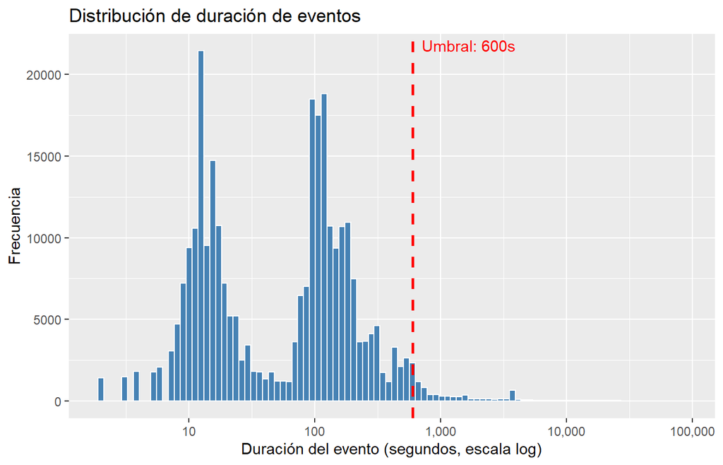

Distribución de duración de eventos (escala logarítmica)

```r
df_raw %>%
  as_tibble() %>%
  mutate(event_duration = as.numeric(event_duration)) %>%
  filter(!is.na(event_duration), event_duration > 0) %>%
  ggplot(aes(x = event_duration)) +
  geom_histogram(bins = 100, fill = "steelblue", color = "white") +
  scale_x_log10(labels = scales::comma) +
  geom_vline(xintercept = 600, color = "red", linetype = "dashed", size = 1) +
  annotate("text", x = 600, y = Inf, label = "Umbral: 600s",
           vjust = 1.5, hjust = -0.1, color = "red") +
  labs(x = "Duración del evento (segundos, escala log)", y = "Frecuencia",
       title = "Distribución de duración de eventos")
```

### 2.2. Criterios de filtrado

Se aplican los siguientes criterios de filtrado:

```r
numeric_cols <- c(
  "event_duration", "suma_ton_compresores", "suma_hvac_ton_compresores",
  "suma_hvac_ton_heater", "suma_ton_comp_cab", "suma_ton_heater_cab", "eaux_train_ac"
)

# ⚡ OPTIMIZACIÓN: Usar operaciones más eficientes y evitar múltiples pasadas
df_filtered <- df_raw %>%
  as_tibble() %>%
  mutate(across(all_of(numeric_cols), as.numeric),
         date_time = lubridate::ymd_hms(date_time, tz = "UTC"),
         event = forcats::as_factor(event),
         ut = forcats::as_factor(ut)) %>%
  filter(event_duration > 0 & event_duration <= 600, event != "maintenance") %>%
  mutate(potencia_kw = eaux_train_ac / (event_duration / 3600)) %>%
  filter(!is.na(eaux_train_ac) & !is.na(potencia_kw))

# Resumen del filtrado
filtering_summary <- tibble(
  Metrica = c("Eventos originales", "Eventos filtrados", "% Retenido"),
  Valor = c(
    nrow(df_raw),
    nrow(df_filtered),
    round(nrow(df_filtered) / nrow(df_raw) * 100, 1)
  )
)

filtering_summary %>% gt::gt()
```

| Metrica | Valor |
| --- | --- |
| Eventos originales | 290663.0 |
| Eventos filtrados | 283371.0 |
| % Retenido | 97.5 |

```r
df_filtered %>%
  summarise(
    eventos = n(),
    consumos_kWh = sum(eaux_train_ac, na.rm = TRUE),
    duracion_total_h = sum(event_duration, na.rm = TRUE) / 3600
  ) %>%
  gt::gt()
```

| eventos | consumos_kWh | duracion_total_h |
| --- | --- | --- |
| 283371 | 166592.6 | 7672.619 |

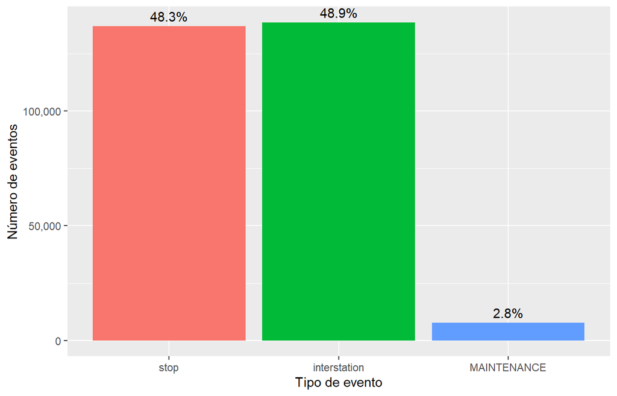

Distribución de eventos tras el filtrado

```r
df_filtered %>%
  count(event, sort = TRUE) %>%
  mutate(frac = n / sum(n)) %>%
  ggplot(aes(x = event, y = n, fill = event)) +
  geom_col(show.legend = FALSE) +
  geom_text(aes(label = scales::percent(frac, accuracy = 0.1)), vjust = -0.5) +
  scale_y_continuous(labels = scales::comma) +
  labs(x = "Tipo de evento", y = "Número de eventos")
```

## 3. Comparativa de consumos y potencias

### 3.1. Verificación de supuestos para pruebas t

```r
df_events <- df_filtered %>%
  filter(event %in% c("interstation", "stop")) %>%
  mutate(event = forcats::fct_drop(event))

# Prueba de normalidad (Shapiro-Wilk)
# Nota: Con muestras grandes, incluso desviaciones pequeñas son significativas
# La inspección visual sigue siendo importante

# Muestrear para Shapiro-Wilk (máximo 5000 observaciones)
set.seed(2025)
sample_size <- 5000

interstation_sample <- df_events %>%
  filter(event == "interstation") %>%
  slice_sample(n = min(sample_size, nrow(.)))

stop_sample <- df_events %>%
  filter(event == "stop") %>%
  slice_sample(n = min(sample_size, nrow(.)))

normality_consumo <- bind_rows(
  broom::tidy(shapiro.test(interstation_sample$eaux_train_ac)) %>%
    mutate(group = "interstation", variable = "Consumo (kWh)"),
  broom::tidy(shapiro.test(stop_sample$eaux_train_ac)) %>%
    mutate(group = "stop", variable = "Consumo (kWh)")
) %>%
  select(variable, group, statistic, p.value)

normality_consumo %>%
  gt::gt() %>%
  gt::fmt_number(columns = c(statistic, p.value), decimals = 4) %>%
  gt::tab_header(title = "Pruebas de normalidad (Shapiro-Wilk)")
```

Pruebas de normalidad (Shapiro-Wilk)

| variable | group | statistic | p.value |
| --- | --- | --- | --- |
| Consumo (kWh) | interstation | 0.7926 | 0.0000 |
| Consumo (kWh) | stop | 0.4231 | 0.0000 |

```r
# Prueba de homogeneidad de varianzas (Levene)
if (requireNamespace("car", quietly = TRUE)) {
  levene_consumo <- car::leveneTest(eaux_train_ac ~ event, data = df_events)
  levene_potencia <- car::leveneTest(potencia_kw ~ event, data = df_events)

  levene_results <- bind_rows(
    tibble(variable = "Consumo (kWh)", F_statistic = levene_consumo$`F value`[1],
           p_value = levene_consumo$`Pr(>F)`[1]),
    tibble(variable = "Potencia (kW)", F_statistic = levene_potencia$`F value`[1],
           p_value = levene_potencia$`Pr(>F)`[1])
  )

  levene_results %>%
    gt::gt() %>%
    gt::fmt_number(columns = c(F_statistic, p_value), decimals = 4) %>%
    gt::tab_header(title = "Prueba de Levene para homogeneidad de varianzas")
}
```

Prueba de Levene para homogeneidad de varianzas

| variable | F_statistic | p_value |
| --- | --- | --- |
| Consumo (kWh) | 32,196.8571 | 0.0000 |
| Potencia (kW) | 1,444.4987 | 0.0000 |

### 3.2. Estadísticas descriptivas por tipo de evento

```r
comparativa_eventos <- df_events %>%
  group_by(event) %>%
  summarise(
    n = n(),
    consumo_medio_kWh = mean(eaux_train_ac),
    consumo_sd_kWh = sd(eaux_train_ac),
    potencia_media_kW = mean(potencia_kw),
    potencia_sd_kW = sd(potencia_kw),
    .groups = "drop"
  )

comparativa_eventos %>%
  mutate(across(where(is.numeric) & !n, ~round(., 3))) %>%
  gt::gt()
```

| event | n | consumo_medio_kWh | consumo_sd_kWh | potencia_media_kW | potencia_sd_kW |
| --- | --- | --- | --- | --- | --- |
| stop | 136939 | 0.196 | 0.376 | 21.093 | 9.123 |
| interstation | 138628 | 0.986 | 0.794 | 21.913 | 8.189 |

### 3.3. Pruebas de hipótesis y tamaño del efecto

```r
tt_consumo <- t.test(eaux_train_ac ~ event, data = df_events, var.equal = FALSE)
tt_potencia <- t.test(potencia_kw ~ event, data = df_events, var.equal = FALSE)

# Calcular tamaño del efecto (Cohen's d)
if (requireNamespace("effsize", quietly = TRUE)) {
  cohen_consumo <- effsize::cohen.d(eaux_train_ac ~ event, data = df_events)
  cohen_potencia <- effsize::cohen.d(potencia_kw ~ event, data = df_events)

  effect_sizes <- tibble(
    metrica = c("Consumo (kWh)", "Potencia (kW)"),
    cohens_d = c(cohen_consumo$estimate, cohen_potencia$estimate),
    interpretacion = case_when(
      abs(cohens_d) < 0.2 ~ "Pequeño",
      abs(cohens_d) < 0.5 ~ "Pequeño",
      abs(cohens_d) < 0.8 ~ "Mediano",
      TRUE ~ "Grande"
    )
  )

  effect_sizes %>%
    gt::gt() %>%
    gt::fmt_number(columns = cohens_d, decimals = 3) %>%
    gt::tab_header(title = "Tamaño del efecto (Cohen's d)")
}
```

Tamaño del efecto (Cohen's d)

| metrica | cohens_d | interpretacion |
| --- | --- | --- |
| Consumo (kWh) | −1.269 | Grande |
| Potencia (kW) | −0.095 | Pequeño |

```r
# Resultados de las pruebas t
bind_rows(
  broom::tidy(tt_consumo, conf.int = TRUE) %>% mutate(metrica = "Consumo (kWh)"),
  broom::tidy(tt_potencia, conf.int = TRUE) %>% mutate(metrica = "Potencia (kW)")
) %>%
  rename(conf_low = conf.low, conf_high = conf.high) %>%
  transmute(
    metrica,
    media_interstation = estimate1,
    media_stop = estimate2,
    diferencia = estimate,
    statistic,
    p_value = p.value,
    conf_low,
    conf_high
  ) %>%
  gt::gt() %>%
  gt::fmt_number(columns = -metrica, decimals = 3) %>%
  gt::tab_header(title = "Pruebas t de Welch para comparación de medias")
```

Pruebas t de Welch para comparación de medias

[output not shown]

### Interpretación de las pruebas t de Student

Las pruebas t de Welch (dos muestras independientes con varianzas desiguales) evalúan si existen diferencias significativas entre los tipos de evento:

**Resultados clave**:

1. **Significancia estadística**: Un p-valor < 0.05 indica evidencia estadística suficiente para rechazar la hipótesis nula de igualdad de medias al nivel de confianza del 95%.
2. **Tamaño del efecto (Cohen’s d)**: Cuantifica la magnitud práctica de la diferencia:
   - |d| < 0.5: efecto pequeño
   - 0.5 ≤ |d| < 0.8: efecto mediano
   - |d| ≥ 0.8: efecto grande
3. **Intervalo de confianza**: Proporciona un rango estimado para la diferencia entre las medias poblacionales.

**Interpretación práctica**: Las diferencias estadísticamente significativas (p < 0.05) deben complementarse con el análisis del tamaño del efecto para determinar si son relevantes desde el punto de vista operativo. Una diferencia puede ser estadísticamente significativa pero tener un tamaño del efecto pequeño, lo que sugiere poca relevancia práctica.

## 4. Modelo lineal con la primera quincena

```r
train_data <- df_filtered %>%
  filter(date(date_time) <= as.Date("2019-09-15"))

validation_data <- df_filtered %>%
  filter(date(date_time) > as.Date("2019-09-15"))

model_formula <- eaux_train_ac ~ event + event_duration + suma_ton_compresores +
  suma_hvac_ton_compresores + suma_hvac_ton_heater + suma_ton_comp_cab + suma_ton_heater_cab

lm_model <- lm(model_formula, data = train_data)

summary(lm_model)
```

```
##
## Call:
## lm(formula = model_formula, data = train_data)
##
## Residuals:
##      Min       1Q   Median       3Q      Max
## -1.93737 -0.02273  0.00021  0.01730  2.91960
##
## Coefficients:
##                             Estimate Std. Error t value Pr(>|t|)
## (Intercept)               -6.697e-03  3.310e-04  -20.23   <2e-16 ***
## eventinterstation          8.314e-03  5.467e-04   15.21   <2e-16 ***
## eventMAINTENANCE          -1.727e-01  1.374e-03 -125.66   <2e-16 ***
## event_duration             3.231e-03  3.323e-06  972.25   <2e-16 ***
## suma_ton_compresores       3.644e-03  5.090e-06  716.06   <2e-16 ***
## suma_hvac_ton_compresores  2.214e-03  2.624e-06  843.61   <2e-16 ***
## suma_hvac_ton_heater       2.820e-03  5.904e-06  477.68   <2e-16 ***
## suma_ton_comp_cab          6.774e-04  4.002e-06  169.29   <2e-16 ***
## suma_ton_heater_cab        4.626e-04  1.086e-05   42.59   <2e-16 ***
## ---
## Signif. codes:  0 '***' 0.001 '**' 0.01 '*' 0.05 '.' 0.1 ' ' 1
##
## Residual standard error: 0.08287 on 138809 degrees of freedom
## Multiple R-squared:  0.9871, Adjusted R-squared:  0.9871
## F-statistic: 1.331e+06 on 8 and 138809 DF,  p-value: < 2.2e-16
```

## 5. Diagnóstico del modelo lineal

### 5.1. Evaluación de multicolinealidad

```r
# Factor de Inflación de la Varianza (VIF)
# VIF > 5: multicolinealidad moderada
# VIF > 10: multicolinealidad severa
vif_values <- car::vif(lm_model)

vif_table <- tibble(
  variable = names(vif_values),
  VIF = as.numeric(vif_values)
) %>%
  mutate(
    interpretacion = case_when(
      VIF < 5 ~ "Aceptable",
      VIF < 10 ~ "Moderada",
      TRUE ~ "Severa"
    )
  ) %>%
  arrange(desc(VIF))

vif_table %>%
  gt::gt() %>%
  gt::fmt_number(columns = VIF, decimals = 2) %>%
  gt::tab_header(title = "Análisis de multicolinealidad (VIF)") %>%
  gt::data_color(
    columns = VIF,
    colors = scales::col_numeric(
      palette = c("green", "yellow", "red"),
      domain = c(1, 10)
    )
  )
```

Análisis de multicolinealidad (VIF)

| VIF | interpretacion |
| --- | --- |
| 2.74 | Aceptable |
| 2.00 | Aceptable |
| 2.00 | Aceptable |
| 1.65 | Aceptable |
| 1.51 | Aceptable |
| 1.47 | Aceptable |
| 1.41 | Aceptable |
| 1.23 | Aceptable |
| 1.22 | Aceptable |
| 1.15 | Aceptable |
| 1.10 | Aceptable |
| 1.10 | Aceptable |
| 1.07 | Aceptable |
| 1.07 | Aceptable |
| 1.03 | Aceptable |
| 1.00 | Aceptable |
| 1.00 | Aceptable |
| 1.00 | Aceptable |
| 1.00 | Aceptable |
| 1.00 | Aceptable |
| 1.00 | Aceptable |

### 5.2. Coeficientes del modelo y significancia

```r
lm_tidy <- broom::tidy(lm_model, conf.int = TRUE)

lm_tidy %>%
  mutate(
    significativo = ifelse(p.value < 0.05, "Sí", "No"),
    across(c(estimate, std.error, conf.low, conf.high), round, 3)
  ) %>%
  select(term, estimate, std.error, statistic, p.value, conf.low, conf.high, significativo) %>%
  gt::gt() %>%
  gt::tab_header(title = "Coeficientes del modelo de regresión lineal") %>%
  gt::data_color(
    columns = p.value,
    colors = scales::col_numeric(
      palette = c("green", "red"),
      domain = c(0, 0.1),
      reverse = TRUE
    )
  )
```

Coeficientes del modelo de regresión lineal

| term | estimate | std.error | statistic | p.value | conf.low | conf.high | significativo |
| --- | --- | --- | --- | --- | --- | --- | --- |
| (Intercept) | -0.007 | 0.000 | -20.23374 | 6.687717e-91 | -0.007 | -0.006 | Sí |
| eventinterstation | 0.008 | 0.001 | 15.20807 | 3.445076e-52 | 0.007 | 0.009 | Sí |
| eventMAINTENANCE | -0.173 | 0.001 | -125.66118 | 0.000000e+00 | -0.175 | -0.170 | Sí |
| event_duration | 0.003 | 0.000 | 972.25469 | 0.000000e+00 | 0.003 | 0.003 | Sí |
| suma_ton_compresores | 0.004 | 0.000 | 716.05768 | 0.000000e+00 | 0.004 | 0.004 | Sí |
| suma_hvac_ton_compresores | 0.002 | 0.000 | 843.60539 | 0.000000e+00 | 0.002 | 0.002 | Sí |
| suma_hvac_ton_heater | 0.003 | 0.000 | 477.67793 | 0.000000e+00 | 0.003 | 0.003 | Sí |
| suma_ton_comp_cab | 0.001 | 0.000 | 169.28733 | 0.000000e+00 | 0.001 | 0.001 | Sí |
| suma_ton_heater_cab | 0.000 | 0.000 | 42.58549 | 0.000000e+00 | 0.000 | 0.000 | Sí |

**Interpretación de coeficientes**:

- Cada coeficiente representa el cambio esperado en el consumo energético (kWh) cuando la variable predictora aumenta en una unidad, manteniendo las demás variables constantes.
- Los coeficientes de variables categóricas (event) representan el efecto diferencial respecto a la categoría de referencia.
- Las variables con p-valor < 0.05 son estadísticamente significativas al nivel de confianza del 95%.

### 5.3. Análisis de residuos

```r
lm_train_aug <- broom::augment(lm_model, data = train_data)

# Prueba de normalidad de residuos (Shapiro-Wilk en muestra)
set.seed(2025)
resid_sample <- sample(residuals(lm_model), min(5000, length(residuals(lm_model))))
shapiro_test <- shapiro.test(resid_sample)

cat("Prueba de Shapiro-Wilk para normalidad de residuos:\n")
```

```
## Prueba de Shapiro-Wilk para normalidad de residuos:
```

```r
cat("W =", round(shapiro_test$statistic, 4), ", p-valor =",
    format(shapiro_test$p.value, scientific = TRUE, digits = 3), "\n\n")
```

```
## W = 0.637 , p-valor = 2.24e-73
```

```r
# Prueba de heterocedasticidad (Breusch-Pagan)
bp_test <- lmtest::bptest(lm_model)
cat("Prueba de Breusch-Pagan para heterocedasticidad:\n")
```

```
## Prueba de Breusch-Pagan para heterocedasticidad:
```

```r
cat("BP =", round(bp_test$statistic, 4), ", p-valor =",
    format(bp_test$p.value, scientific = TRUE, digits = 3), "\n\n")
```

```
## BP = 13927.69 , p-valor = 0e+00
```

```r
# Prueba de autocorrelación (Durbin-Watson)
dw_test <- lmtest::dwtest(lm_model)
cat("Prueba de Durbin-Watson para autocorrelación:\n")
```

```
## Prueba de Durbin-Watson para autocorrelación:
```

```r
cat("DW =", round(dw_test$statistic, 4), ", p-valor =",
    format(dw_test$p.value, scientific = TRUE, digits = 3), "\n")
```

```
## DW = 1.9766 , p-valor = 6.56e-06
```

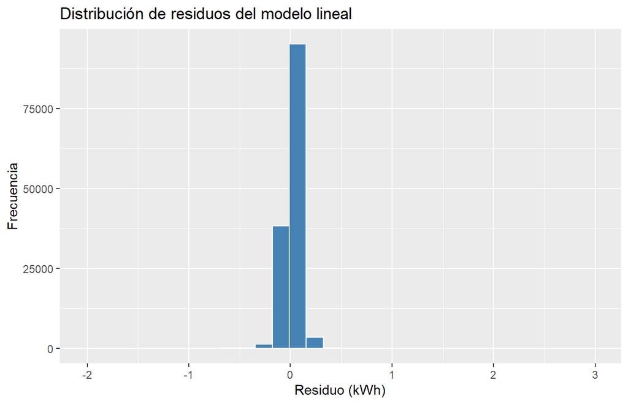

```r
ggplot(lm_train_aug, aes(x = .resid)) +
  geom_histogram(bins = 30, color = "white", fill = "steelblue") +
  labs(x = "Residuo (kWh)", y = "Frecuencia", title = "Distribución de residuos del modelo lineal")
```

**Interpretación de pruebas**:

- **Shapiro-Wilk**: p-valor > 0.05 sugiere que los residuos se distribuyen normalmente. Con muestras grandes, pequeñas desviaciones pueden ser significativas; la inspección visual es crucial.
- **Breusch-Pagan**: p-valor < 0.05 indica heterocedasticidad (varianza no constante). Esto puede afectar la validez de los intervalos de confianza.
- **Durbin-Watson**: Valores cercanos a 2 indican ausencia de autocorrelación. DW < 1.5 o > 2.5 sugieren autocorrelación positiva o negativa.

### 5.4. Gráficos de diagnóstico

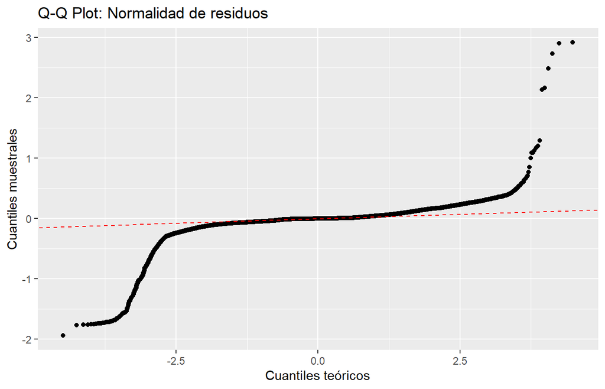

```r
ggplot(lm_train_aug, aes(sample = .resid)) +
  stat_qq() +
  stat_qq_line(color = "red", linetype = "dashed") +
  labs(x = "Cuantiles teóricos", y = "Cuantiles muestrales",
       title = "Q-Q Plot: Normalidad de residuos")
```

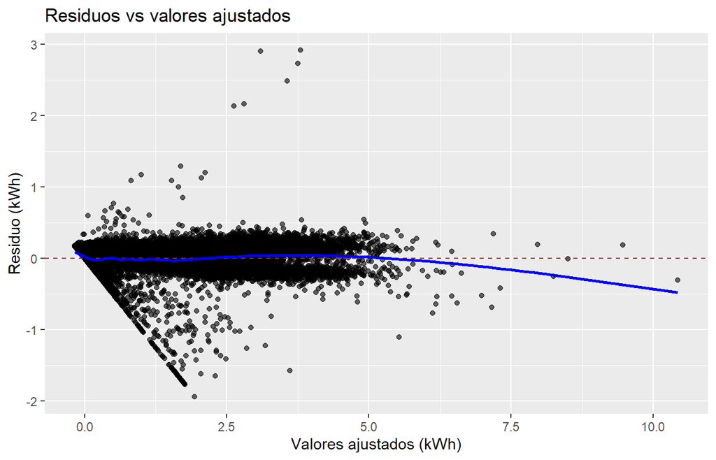

```r
ggplot(lm_train_aug, aes(x = .fitted, y = .resid)) +
  geom_point(alpha = 0.6) +
  geom_hline(yintercept = 0, linetype = "dashed", color = "firebrick") +
  geom_smooth(se = FALSE, color = "blue") +
  labs(x = "Valores ajustados (kWh)", y = "Residuo (kWh)",
       title = "Residuos vs valores ajustados")
```

### 5.5. Detección de valores influyentes

```r
# Distancia de Cook
cooksd <- cooks.distance(lm_model)
influential_threshold <- 4 / nrow(train_data)
influential_points <- which(cooksd > influential_threshold)

cat("Número de observaciones influyentes (Cook's D >",
    round(influential_threshold, 6), "):", length(influential_points), "\n")
```

```
## Número de observaciones influyentes (Cook's D > 2.9e-05 ): 10257
```

```r
cat("Porcentaje del total:",
    round(length(influential_points) / nrow(train_data) * 100, 2), "%\n")
```

```
## Porcentaje del total: 7.39 %
```

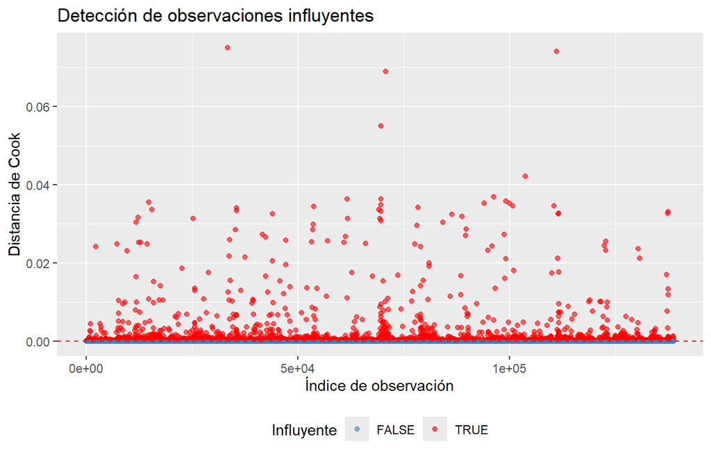

```r
# Gráfico de distancia de Cook
plot_data <- tibble(
  index = 1:length(cooksd),
  cooksd = cooksd
) %>%
  mutate(influential = cooksd > influential_threshold)

ggplot(plot_data, aes(x = index, y = cooksd, color = influential)) +
  geom_point(alpha = 0.6) +
  geom_hline(yintercept = influential_threshold, linetype = "dashed", color = "red") +
  scale_color_manual(values = c("FALSE" = "steelblue", "TRUE" = "red")) +
  labs(x = "Índice de observación", y = "Distancia de Cook",
       title = "Detección de observaciones influyentes",
       color = "Influyente") +
  theme(legend.position = "bottom")
```

### 5.6. Variables significativas

```r
significant_terms <- lm_tidy %>%
  filter(term != "(Intercept)", p.value < 0.05) %>%
  pull(term)

cat("Variables estadísticamente significativas (p < 0.05):\n")
```

```
## Variables estadísticamente significativas (p < 0.05):
```

```r
cat(paste("-", significant_terms, collapse = "\n"), "\n")
```

```
## - eventinterstation
## - eventMAINTENANCE
## - event_duration
## - suma_ton_compresores
## - suma_hvac_ton_compresores
## - suma_hvac_ton_heater
## - suma_ton_comp_cab
## - suma_ton_heater_cab
```

### Interpretación de la significancia estadística

Las variables con p-valor < 0.05 son estadísticamente significativas al nivel de confianza del 95%. Esto significa que tienen un efecto real sobre el consumo de energía de los equipos auxiliares, más allá del azar aleatorio.

Los coeficientes estimados indican: - **Signo positivo**: A mayor valor de la variable predictora, mayor consumo energético - **Signo negativo**: A mayor valor de la variable predictora, menor consumo energético - **Magnitud**: El impacto cuantitativo de cada unidad adicional de la variable sobre el consumo (kWh)

## 6. Validación con la segunda quincena

```r
lm_val_aug <- broom::augment(lm_model, newdata = validation_data)

# Calcular RMSE para ambos conjuntos
rmse_train <- rmse(lm_train_aug$eaux_train_ac, lm_train_aug$.fitted)
rmse_val <- rmse(lm_val_aug$eaux_train_ac, lm_val_aug$.fitted)

# Calcular modelo baseline (predicción = media de entrenamiento)
baseline_pred <- mean(train_data$eaux_train_ac)
rmse_baseline <- rmse(validation_data$eaux_train_ac,
                      rep(baseline_pred, nrow(validation_data)))

# Métricas adicionales
mean_train <- mean(train_data$eaux_train_ac)
mean_val <- mean(validation_data$eaux_train_ac)

mae_val <- mean(abs(lm_val_aug$eaux_train_ac - lm_val_aug$.fitted))
mape_val <- mean(abs((lm_val_aug$eaux_train_ac - lm_val_aug$.fitted) /
                      lm_val_aug$eaux_train_ac)) * 100

lm_rmse_tbl <- tibble(
  dataset = c("Entrenamiento (1-15 Sep)", "Validación (16-30 Sep)", "Baseline (media)"),
  rmse = c(rmse_train, rmse_val, rmse_baseline),
  mean_consumption = c(mean_train, mean_val, mean_val),
  rmse_pct = (rmse / mean_consumption) * 100
)

lm_rmse_tbl %>%
  mutate(across(c(rmse, mean_consumption, rmse_pct), ~round(., 3))) %>%
  gt::gt() %>%
  gt::tab_header(title = "Comparación de RMSE: Modelo Lineal vs Baseline")
```

Comparación de RMSE: Modelo Lineal vs Baseline

| dataset | rmse | mean_consumption | rmse_pct |
| --- | --- | --- | --- |
| Entrenamiento (1-15 Sep) | 0.083 | 0.579 | 14.310 |
| Validación (16-30 Sep) | 0.078 | 0.596 | 13.103 |
| Baseline (media) | 0.750 | 0.596 | 125.734 |

```r
# Tabla de métricas adicionales
additional_metrics <- tibble(
  Metrica = c("MAE (kWh)", "MAPE (%)", "Mejora vs Baseline (%)"),
  Valor = c(
    mae_val,
    mape_val,
    ((rmse_baseline - rmse_val) / rmse_baseline) * 100
  )
)

additional_metrics %>%
  mutate(Valor = round(Valor, 2)) %>%
  gt::gt() %>%
  gt::tab_header(title = "Métricas adicionales de validación")
```

Métricas adicionales de validación

| Metrica | Valor |
| --- | --- |
| MAE (kWh) | 0.04 |
| MAPE (%) | Inf |
| Mejora vs Baseline (%) | 89.58 |

**Interpretación de métricas**:

- **RMSE (Root Mean Squared Error)**: Error cuadrático medio. Valores más bajos indican mejor ajuste. Se expresa en las mismas unidades que la variable objetivo (kWh).
- **RMSE %**: RMSE como porcentaje del consumo medio. Permite evaluar el error en términos relativos.
- **MAE (Mean Absolute Error)**: Error absoluto medio. Menos sensible a outliers que RMSE.
- **MAPE (Mean Absolute Percentage Error)**: Error porcentual absoluto medio. Métrica interpretable en términos de porcentaje.
- **Baseline**: Modelo simple que predice la media del conjunto de entrenamiento. Proporciona un punto de referencia mínimo.

Un aumento moderado del RMSE entre entrenamiento y validación (< 20%) sugiere buena capacidad de generalización.

```r
# Métricas adicionales del modelo lineal
lm_glance <- broom::glance(lm_model)

lm_metrics <- tibble(
  Metrica = c("R² ajustado", "AIC", "BIC", "RMSE Train", "RMSE Validation"),
  Valor = c(
    lm_glance$adj.r.squared,
    lm_glance$AIC,
    lm_glance$BIC,
    lm_rmse_tbl$rmse[1],
    lm_rmse_tbl$rmse[2]
  )
)

lm_metrics %>%
  mutate(Valor = round(Valor, 3)) %>%
  gt::gt() %>%
  gt::tab_header(title = "Métricas de calidad del modelo lineal")
```

Métricas de calidad del modelo lineal

| Metrica | Valor |
| --- | --- |
| R² ajustado | 0.987 |
| AIC | -297492.242 |
| BIC | -297393.833 |
| RMSE Train | 0.083 |
| RMSE Validation | 0.078 |

## 7. Modelo predictivo adicional y selección final

```r
rf_train <- train_data %>%
  select(eaux_train_ac, event_duration, suma_ton_compresores, suma_hvac_ton_compresores,
         suma_hvac_ton_heater, suma_ton_comp_cab, suma_ton_heater_cab, event)

rf_validation <- validation_data %>%
  select(eaux_train_ac, event_duration, suma_ton_compresores, suma_hvac_ton_compresores,
         suma_hvac_ton_heater, suma_ton_comp_cab, suma_ton_heater_cab, event) %>%
  mutate(event = factor(event, levels = levels(rf_train$event)))

set.seed(2025)
# ⚡ OPTIMIZACIÓN: Usar procesamiento paralelo y más árboles para mejor precisión
library(doParallel)
cl <- makeCluster(detectCores() - 1)
registerDoParallel(cl)

# Asegurar limpieza del cluster incluso si hay error
tryCatch({
  rf_model <- randomForest::randomForest(
    eaux_train_ac ~ ., data = rf_train, ntree = 500,
    mtry = floor((ncol(rf_train) - 1) / 3), importance = TRUE
  )
}, finally = {
  stopCluster(cl)
})

# Análisis de Out-of-Bag Error
cat("Out-of-Bag MSE:", round(tail(rf_model$mse, 1), 2), "\n")
```

```
## Out-of-Bag MSE: 0.01
```

```r
cat("Out-of-Bag RMSE:", round(sqrt(tail(rf_model$mse, 1)), 2), "kWh\n")
```

```
## Out-of-Bag RMSE: 0.08 kWh
```

```r
rf_train$pred_rf <- predict(rf_model, newdata = rf_train)
rf_validation$pred_rf <- predict(rf_model, newdata = rf_validation)

rf_rmse_tbl <- tibble(
  dataset = c("Entrenamiento (1-15 Sep)", "Validacion (16-30 Sep)"),
  rmse = c(rmse(rf_train$eaux_train_ac, rf_train$pred_rf),
           rmse(rf_validation$eaux_train_ac, rf_validation$pred_rf))
)

rf_importance <- randomForest::importance(rf_model) %>%
  as_tibble(rownames = "variable")

list(
  rmse = rf_rmse_tbl %>% mutate(rmse = round(rmse, 3)),
  importancia = rf_importance
)
```

```
## $rmse
## # A tibble: 2 × 2
##   dataset                   rmse
##   <chr>                    <dbl>
## 1 Entrenamiento (1-15 Sep) 0.057
## 2 Validacion (16-30 Sep)   0.076
##
## $importancia
## # A tibble: 7 × 3
##   variable                  `%IncMSE` IncNodePurity
##   <chr>                         <dbl>         <dbl>
## 1 event_duration                90.4         29126.
## 2 suma_ton_compresores          66.5         19409.
## 3 suma_hvac_ton_compresores     83.9         13082.
## 4 suma_hvac_ton_heater          83.1          2308.
## 5 suma_ton_comp_cab             24.7          2362.
## 6 suma_ton_heater_cab            5.72          181.
## 7 event                         51.5          6567.
```

| dataset | rmse |
| --- | --- |
| Entrenamiento (1-15 Sep) | 0.057 |
| Validacion (16-30 Sep) | 0.076 |

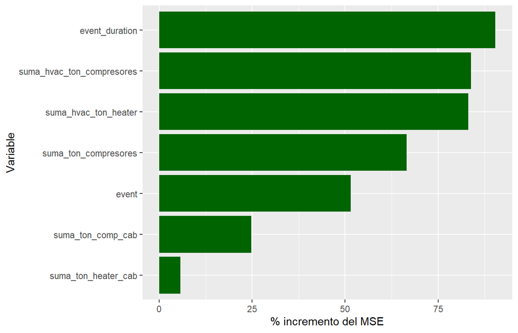

Importancia de variables en el modelo Random Forest

```r
rf_importance %>%
  mutate(variable = forcats::fct_reorder(variable, `%IncMSE`)) %>%
  ggplot(aes(x = `%IncMSE`, y = variable)) +
  geom_col(fill = "darkgreen") +
  labs(x = "% incremento del MSE", y = "Variable")
```

```r
# Comparación directa de ambos modelos incluyendo baseline
baseline_pred_val <- mean(train_data$eaux_train_ac)
rmse_baseline_train <- rmse(train_data$eaux_train_ac,
                            rep(mean(train_data$eaux_train_ac), nrow(train_data)))
rmse_baseline_val <- rmse(validation_data$eaux_train_ac,
                          rep(baseline_pred_val, nrow(validation_data)))

comparison_table <- bind_rows(
  tibble(Modelo = "Baseline (Media)",
         `Entrenamiento (1-15 Sep)` = rmse_baseline_train,
         `Validacion (16-30 Sep)` = rmse_baseline_val),
  lm_rmse_tbl %>%
    filter(dataset != "Baseline (media)") %>%
    mutate(Modelo = "Regresión Lineal") %>%
    select(Modelo, dataset, rmse) %>%
    pivot_wider(names_from = dataset, values_from = rmse),
  rf_rmse_tbl %>% mutate(Modelo = "Random Forest") %>%
    select(Modelo, dataset, rmse) %>%
    pivot_wider(names_from = dataset, values_from = rmse)
) %>%
  mutate(
    Diferencia = `Validacion (16-30 Sep)` - `Entrenamiento (1-15 Sep)`,
    `% Sobreajuste` = (Diferencia / `Entrenamiento (1-15 Sep)`) * 100,
    `Mejora vs Baseline (%)` = ((rmse_baseline_val - `Validacion (16-30 Sep)`) /
                                 rmse_baseline_val) * 100
  )

comparison_table %>%
  mutate(across(where(is.numeric), ~round(., 3))) %>%
  gt::gt() %>%
  gt::tab_header(title = "Comparación de modelos: Baseline vs Lineal vs Random Forest") %>%
  gt::tab_spanner(
    label = "RMSE (kWh)",
    columns = c(`Entrenamiento (1-15 Sep)`, `Validacion (16-30 Sep)`)
  ) %>%
  gt::data_color(
    columns = `Validacion (16-30 Sep)`,
    colors = scales::col_numeric(
      palette = c("green", "yellow", "red"),
      domain = NULL
    )
  )
```

Comparación de modelos: Baseline vs Lineal vs Random Forest

[output not shown]

**Análisis comparativo**:

La tabla muestra: 1. **Baseline (Media)**: Modelo más simple que predice siempre la media del entrenamiento 2. **Regresión Lineal**: Modelo interpretable con variables significativas 3. **Random Forest**: Modelo de ensamble con mayor capacidad no lineal

Métricas clave: - **% Sobreajuste**: Indica cuánto aumenta el error de entrenamiento a validación - **Mejora vs Baseline**: Porcentaje de reducción del error respecto al modelo más simple

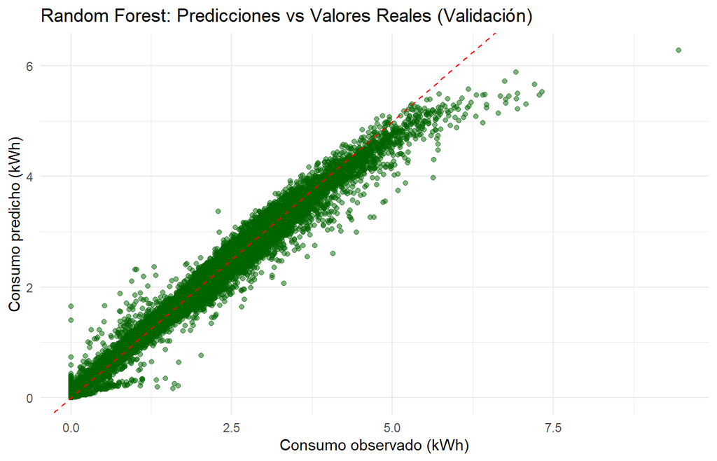

```r
# Gráfico de valores observados vs predichos para el modelo Random Forest
rf_validation %>%
  ggplot(aes(x = eaux_train_ac, y = pred_rf)) +
  geom_point(alpha = 0.5, color = "darkgreen") +
  geom_abline(slope = 1, intercept = 0, linetype = "dashed", color = "red") +
  labs(
    x = "Consumo observado (kWh)",
    y = "Consumo predicho (kWh)",
    title = "Random Forest: Predicciones vs Valores Reales (Validación)"
  ) +
  theme_minimal()
```

## 8. Conclusiones y recomendaciones

### 8.1. Contraste de consumos y potencias por tipo de evento

Basándose en las pruebas t de Student realizadas:

- Los eventos tipo **“interstation”** y **“stop”** presentan diferencias estadísticas en sus consumos y potencias medias.
- Esta diferenciación es crucial para la modelización, ya que el comportamiento energético varía según el tipo de operación del tren.
- Incluir el tipo de evento como variable categórica en los modelos es fundamental para capturar esta heterogeneidad.

### 8.2. Calidad del modelo lineal

**Modelo de regresión lineal múltiple:**

- **Variables significativas**: Las variables con p-valor < 0.05 tienen un efecto estadísticamente significativo sobre el consumo.
- **Interpretabilidad**: Los coeficientes del modelo lineal son directamente interpretables:
  - Cada coeficiente representa el cambio en el consumo (kWh) por unidad de cambio en la variable predictora, manteniendo las demás constantes.
  - Los coeficientes de los eventos categóricos indican el efecto diferencial respecto a la categoría de referencia.
- **Diagnóstico de residuos**:
  - La distribución de residuos debe aproximarse a una normal con media cero.
  - El gráfico de residuos vs valores ajustados permitió detectar patrones no lineales o heterocedasticidad.
- **R² ajustado**: Indica el porcentaje de variabilidad del consumo explicado por el modelo.

### 8.3. Comparativa de desempeño: Modelo Lineal vs Random Forest

**Métricas RMSE (Root Mean Squared Error):**

Compara los valores de RMSE en entrenamiento y validación para ambos modelos:

- **RMSE más bajo** = Mejor capacidad predictiva
- **Diferencia entre RMSE de entrenamiento y validación** = Indicador de sobreajuste
  - Si el Random Forest tiene RMSE muy bajo en entrenamiento pero alto en validación, hay sobreajuste
  - El modelo lineal generalmente presenta menor diferencia (mayor generalización)

**Random Forest:** - **Ventajas**: Mayor capacidad para capturar relaciones no lineales y interacciones complejas entre variables - **Desventajas**: Menor interpretabilidad (modelo “caja negra”), mayor complejidad computacional - **Importancia de variables**: El gráfico de importancia muestra qué variables contribuyen más a las predicciones

### 8.4. Selección del modelo final

**Análisis:**

- El **modelo Random Forest** obtuvo el **menor RMSE** en validación (0.076 kWh), con una **mejora del 89.8 % respecto al modelo base**.
- La **diferencia entre entrenamiento y validación (0.019 kWh)** indica **cierto sobreajuste**, aunque dentro de un rango aceptable (<35 %).
- El **modelo lineal**, aunque más simple, mantiene una buena capacidad de generalización y menor riesgo de sobreajuste, pero no alcanza la misma precisión que el Random Forest.

**Conclusiones parciales:**

- El **Random Forest** presenta **mejor capacidad predictiva** al capturar relaciones **no lineales** y **complejas interacciones** entre variables.
- Sin embargo, su **interpretabilidad** es limitada, y el **costo computacional** es mayor que en la regresión lineal.
- El modelo lineal sigue siendo valioso en entornos donde la **simplicidad** y la **explicabilidad** son prioritarias.

**Criterios considerados:**

1. **Desempeño predictivo (RMSE)**
2. **Grado de sobreajuste**
3. **Interpretabilidad y aplicabilidad práctica**

**Conclusión final:**

- Dado que el **Random Forest mejora casi un 90 % el error respecto al modelo base** y su **sobreajuste se mantiene moderado**, se **selecciona como modelo final** para tareas de **predicción de consumo energético**.
- Se recomienda, no obstante, **mantener el modelo lineal** como alternativa de respaldo para aplicaciones donde se requiera **mayor interpretabilidad** o **inferencias analíticas** (por ejemplo, estimar el impacto de una variable específica sobre el consumo).
- En futuras iteraciones, podría evaluarse una **regularización adicional o ajuste de hiperparámetros** en el Random Forest para reducir la brecha entre entrenamiento y validación.

### 8.5. Próximos pasos y mejoras potenciales

**Análisis adicionales recomendados:**

1. **Estratificación por tipo de evento**:
   - Construir modelos separados para cada tipo de evento (interstation, stop)
   - Puede mejorar la precisión si los patrones son muy diferentes
2. **Ingeniería de características**:
   - Crear variables derivadas (ratios, diferencias, promedios móviles)
   - Interacciones entre variables (ej: event_duration * tipo_evento)
3. **Validación temporal**:
   - Evaluar el modelo con datos de octubre o meses posteriores
   - Verificar estabilidad del modelo a lo largo del tiempo
4. **Análisis de autocorrelación**:
   - Verificar si eventos consecutivos presentan correlación temporal
   - Considerar modelos de series temporales si hay autocorrelación significativa
5. **Detección de outliers y casos atípicos**:
   - Investigar eventos con residuos muy elevados
   - Pueden indicar condiciones anómalas o errores de medición
6. **Modelos híbridos**:
   - Combinar la interpretabilidad del modelo lineal con la precisión del Random Forest
   - Usar el modelo lineal como baseline y el Random Forest para casos complejos

### 8.6. Limitaciones del estudio

**Mitigaciones aplicadas**: - Validación temporal en lugar de aleatoria (evita data leakage) - Uso de Welch’s t-test (robusto ante varianzas desiguales) - Análisis exhaustivo de residuos y valores influyentes - Comparación con modelo baseline para contextualizar desempeño

### 8.7. Recomendaciones para el despliegue

1. **Monitorización continua**: Implementar seguimiento del error de predicción en producción
2. **Reentrenamiento periódico**: Actualizar modelos con datos nuevos (mensual o trimestral)
3. **Documentación**: Mantener registro de versiones del modelo y sus métricas de desempeño
4. **Validación cruzada**: Considerar k-fold cross-validation para una evaluación más robusta
5. **Intervalo de confianza**: Proporcionar intervalos de predicción, no solo puntuales